# Ames 데이터셋 - 데이터 전처리 과정 (데이터 정제 및 특성 엔지니어링) 보기

- https://www.kaggle.com/serigne/stacked-regressions-top-4-on-leaderboard
- 위 링크와 동일한 내용을 단순히 틀 안에 넣어 다시보기

## 0. 불러오기 등 준비

```python
## 준비
print('Ran on Jupyter Notebook')

import sys
print(sys.version) # 파이썬 버전
print(sys.executable) # 파이썬 위치
import os
print(os.getcwd()) # 폴더 위치

import inspect
from datetime import datetime

import pixiedust # 디버깅 툴
# %%pixie_debugger

from IPython.core.display import display, HTML # 셀이 화면 전체 채우도록 함
display(HTML("<style>.container { width:100% !important; }</style>"))
```

```
Ran on Jupyter Notebook
3.6.9 |Anaconda, Inc.| (default, Jul 30 2019, 14:00:49) [MSC v.1915 64 bit (AMD64)]
C:\ProgramData\Anaconda3\python.exe
C:\Users\Administrator\Desktop\D0123_make_lecture_for_tobigs\D0210_실제로_코드_짜기\notebooks
Pixiedust database opened successfully
```

[figure not shown]

Pixiedust version 1.1.18

```python
## 자주 쓰는 모듈들
import pandas as pd
import numpy as np

import sklearn
from sklearn import datasets
from sklearn.model_selection import GridSearchCV
from sklearn.model_selection import RandomizedSearchCV
from sklearn.model_selection import train_test_split
from sklearn.model_selection import cross_val_score
from sklearn import metrics

%matplotlib inline
import matplotlib.pyplot as plt
import seaborn as sns
color = sns.color_palette()
sns.set_style('darkgrid')
```

## 1. 핵심 모듈 및 데이터 불러오기 Import Data

```python
from scipy import stats
from scipy.stats import norm, skew
```

```python
filename = os.path.join('..','input', 'datasets', 'ames', 'ames_train.csv')
train = pd.read_csv(filename)
filename = os.path.join('..','input', 'datasets', 'ames', 'ames_test.csv')
test = pd.read_csv(filename)
```

## 2. 데이터 탐색 Explore Data

```python
def display_data(data, num):
    with pd.option_context('display.max_rows', None, 'display.max_columns', None): # temporarily unleash limit
        print('dataset shape is: {}'.format(data.shape))
        display(data.head(num))
        display(data.sample(num).sort_index())
        display(data.tail(num))
```

```python
display_data(train, 10)
```

```
dataset shape is: (1460, 81)
```

|  | Id | MSSubClass | MSZoning | LotFrontage | LotArea | Street | Alley | LotShape | LandContour | Utilities | LotConfig | LandSlope | Neighborhood | Condition1 | Condition2 | BldgType | HouseStyle | OverallQual | OverallCond | YearBuilt | YearRemodAdd | RoofStyle | RoofMatl | Exterior1st | Exterior2nd | MasVnrType | MasVnrArea | ExterQual | ExterCond | … |
| --- | --- | --- | --- | --- | --- | --- | --- | --- | --- | --- | --- | --- | --- | --- | --- | --- | --- | --- | --- | --- | --- | --- | --- | --- | --- | --- | --- | --- | --- | --- |
| 0 | 1 | 60 | RL | 65.0 | 8450 | Pave | NaN | Reg | Lvl | AllPub | Inside | Gtl | CollgCr | Norm | Norm | 1Fam | 2Story | 7 | 5 | 2003 | 2003 | Gable | CompShg | VinylSd | VinylSd | BrkFace | 196.0 | Gd | TA | … |
| 1 | 2 | 20 | RL | 80.0 | 9600 | Pave | NaN | Reg | Lvl | AllPub | FR2 | Gtl | Veenker | Feedr | Norm | 1Fam | 1Story | 6 | 8 | 1976 | 1976 | Gable | CompShg | MetalSd | MetalSd | None | 0.0 | TA | TA | … |
| 2 | 3 | 60 | RL | 68.0 | 11250 | Pave | NaN | IR1 | Lvl | AllPub | Inside | Gtl | CollgCr | Norm | Norm | 1Fam | 2Story | 7 | 5 | 2001 | 2002 | Gable | CompShg | VinylSd | VinylSd | BrkFace | 162.0 | Gd | TA | … |
| 3 | 4 | 70 | RL | 60.0 | 9550 | Pave | NaN | IR1 | Lvl | AllPub | Corner | Gtl | Crawfor | Norm | Norm | 1Fam | 2Story | 7 | 5 | 1915 | 1970 | Gable | CompShg | Wd Sdng | Wd Shng | None | 0.0 | TA | TA | … |
| 4 | 5 | 60 | RL | 84.0 | 14260 | Pave | NaN | IR1 | Lvl | AllPub | FR2 | Gtl | NoRidge | Norm | Norm | 1Fam | 2Story | 8 | 5 | 2000 | 2000 | Gable | CompShg | VinylSd | VinylSd | BrkFace | 350.0 | Gd | TA | … |
| 5 | 6 | 50 | RL | 85.0 | 14115 | Pave | NaN | IR1 | Lvl | AllPub | Inside | Gtl | Mitchel | Norm | Norm | 1Fam | 1.5Fin | 5 | 5 | 1993 | 1995 | Gable | CompShg | VinylSd | VinylSd | None | 0.0 | TA | TA | … |
| 6 | 7 | 20 | RL | 75.0 | 10084 | Pave | NaN | Reg | Lvl | AllPub | Inside | Gtl | Somerst | Norm | Norm | 1Fam | 1Story | 8 | 5 | 2004 | 2005 | Gable | CompShg | VinylSd | VinylSd | Stone | 186.0 | Gd | TA | … |
| 7 | 8 | 60 | RL | NaN | 10382 | Pave | NaN | IR1 | Lvl | AllPub | Corner | Gtl | NWAmes | PosN | Norm | 1Fam | 2Story | 7 | 6 | 1973 | 1973 | Gable | CompShg | HdBoard | HdBoard | Stone | 240.0 | TA | TA | … |
| 8 | 9 | 50 | RM | 51.0 | 6120 | Pave | NaN | Reg | Lvl | AllPub | Inside | Gtl | OldTown | Artery | Norm | 1Fam | 1.5Fin | 7 | 5 | 1931 | 1950 | Gable | CompShg | BrkFace | Wd Shng | None | 0.0 | TA | TA | … |
| 9 | 10 | 190 | RL | 50.0 | 7420 | Pave | NaN | Reg | Lvl | AllPub | Corner | Gtl | BrkSide | Artery | Artery | 2fmCon | 1.5Unf | 5 | 6 | 1939 | 1950 | Gable | CompShg | MetalSd | MetalSd | None | 0.0 | TA | TA | … |

|  | Id | MSSubClass | MSZoning | LotFrontage | LotArea | Street | Alley | LotShape | LandContour | Utilities | LotConfig | LandSlope | Neighborhood | Condition1 | Condition2 | BldgType | HouseStyle | OverallQual | OverallCond | YearBuilt | YearRemodAdd | RoofStyle | RoofMatl | Exterior1st | Exterior2nd | MasVnrType | MasVnrArea | ExterQual | ExterCond | … |
| --- | --- | --- | --- | --- | --- | --- | --- | --- | --- | --- | --- | --- | --- | --- | --- | --- | --- | --- | --- | --- | --- | --- | --- | --- | --- | --- | --- | --- | --- | --- |
| 11 | 12 | 60 | RL | 85.0 | 11924 | Pave | NaN | IR1 | Lvl | AllPub | Inside | Gtl | NridgHt | Norm | Norm | 1Fam | 2Story | 9 | 5 | 2005 | 2006 | Hip | CompShg | WdShing | Wd Shng | Stone | 286.0 | Ex | TA | … |
| 220 | 221 | 20 | RL | 73.0 | 8990 | Pave | NaN | IR1 | Lvl | AllPub | Inside | Gtl | CollgCr | Norm | Norm | 1Fam | 1Story | 7 | 5 | 2006 | 2006 | Gable | CompShg | VinylSd | VinylSd | None | 0.0 | Gd | TA | … |
| 239 | 240 | 50 | RL | 52.0 | 8741 | Pave | NaN | Reg | Lvl | AllPub | Inside | Gtl | Edwards | Norm | Norm | 1Fam | 1.5Fin | 6 | 4 | 1945 | 1950 | Gable | CompShg | VinylSd | VinylSd | None | 0.0 | TA | TA | … |
| 256 | 257 | 60 | FV | 64.0 | 8791 | Pave | NaN | IR1 | Lvl | AllPub | Inside | Gtl | Somerst | Norm | Norm | 1Fam | 2Story | 6 | 5 | 2003 | 2003 | Gable | CompShg | VinylSd | VinylSd | None | 0.0 | Gd | TA | … |
| 666 | 667 | 60 | RL | NaN | 18450 | Pave | NaN | IR1 | Lvl | AllPub | Inside | Gtl | NAmes | Norm | Norm | 1Fam | 2Story | 6 | 5 | 1965 | 1979 | Flat | Tar&Grv | Plywood | Plywood | BrkCmn | 113.0 | TA | Gd | … |
| 728 | 729 | 90 | RL | 85.0 | 11475 | Pave | NaN | Reg | Lvl | AllPub | Corner | Gtl | NAmes | Norm | Norm | Duplex | 1Story | 5 | 5 | 1958 | 1958 | Gable | CompShg | VinylSd | VinylSd | BrkFace | 95.0 | TA | TA | … |
| 878 | 879 | 85 | RL | 88.0 | 11782 | Pave | NaN | IR1 | Lvl | AllPub | Inside | Gtl | Sawyer | Norm | Norm | 1Fam | SFoyer | 5 | 7 | 1961 | 1995 | Gable | CompShg | HdBoard | HdBoard | None | 0.0 | TA | TA | … |
| 1127 | 1128 | 20 | RL | 182.0 | 14572 | Pave | NaN | IR3 | Lvl | AllPub | Corner | Gtl | Gilbert | Norm | Norm | 1Fam | 1Story | 7 | 5 | 2004 | 2004 | Hip | CompShg | VinylSd | VinylSd | None | 0.0 | Gd | TA | … |
| 1130 | 1131 | 50 | RL | 65.0 | 7804 | Pave | NaN | Reg | Lvl | AllPub | Inside | Gtl | SWISU | Norm | Norm | 1Fam | 1.5Fin | 4 | 3 | 1928 | 1950 | Gable | CompShg | WdShing | Plywood | None | 0.0 | TA | TA | … |
| 1291 | 1292 | 160 | RM | 21.0 | 1680 | Pave | NaN | Reg | Lvl | AllPub | Inside | Gtl | BrDale | Norm | Norm | Twnhs | 2Story | 5 | 7 | 1972 | 1972 | Gable | CompShg | CemntBd | CmentBd | BrkFace | 268.0 | TA | TA | … |

|  | Id | MSSubClass | MSZoning | LotFrontage | LotArea | Street | Alley | LotShape | LandContour | Utilities | LotConfig | LandSlope | Neighborhood | Condition1 | Condition2 | BldgType | HouseStyle | OverallQual | OverallCond | YearBuilt | YearRemodAdd | RoofStyle | RoofMatl | Exterior1st | Exterior2nd | MasVnrType | MasVnrArea | ExterQual | ExterCond | … |
| --- | --- | --- | --- | --- | --- | --- | --- | --- | --- | --- | --- | --- | --- | --- | --- | --- | --- | --- | --- | --- | --- | --- | --- | --- | --- | --- | --- | --- | --- | --- |
| 1450 | 1451 | 90 | RL | 60.0 | 9000 | Pave | NaN | Reg | Lvl | AllPub | FR2 | Gtl | NAmes | Norm | Norm | Duplex | 2Story | 5 | 5 | 1974 | 1974 | Gable | CompShg | VinylSd | VinylSd | None | 0.0 | TA | TA | … |
| 1451 | 1452 | 20 | RL | 78.0 | 9262 | Pave | NaN | Reg | Lvl | AllPub | Inside | Gtl | Somerst | Norm | Norm | 1Fam | 1Story | 8 | 5 | 2008 | 2009 | Gable | CompShg | CemntBd | CmentBd | Stone | 194.0 | Gd | TA | … |
| 1452 | 1453 | 180 | RM | 35.0 | 3675 | Pave | NaN | Reg | Lvl | AllPub | Inside | Gtl | Edwards | Norm | Norm | TwnhsE | SLvl | 5 | 5 | 2005 | 2005 | Gable | CompShg | VinylSd | VinylSd | BrkFace | 80.0 | TA | TA | … |
| 1453 | 1454 | 20 | RL | 90.0 | 17217 | Pave | NaN | Reg | Lvl | AllPub | Inside | Gtl | Mitchel | Norm | Norm | 1Fam | 1Story | 5 | 5 | 2006 | 2006 | Gable | CompShg | VinylSd | VinylSd | None | 0.0 | TA | TA | … |
| 1454 | 1455 | 20 | FV | 62.0 | 7500 | Pave | Pave | Reg | Lvl | AllPub | Inside | Gtl | Somerst | Norm | Norm | 1Fam | 1Story | 7 | 5 | 2004 | 2005 | Gable | CompShg | VinylSd | VinylSd | None | 0.0 | Gd | TA | … |
| 1455 | 1456 | 60 | RL | 62.0 | 7917 | Pave | NaN | Reg | Lvl | AllPub | Inside | Gtl | Gilbert | Norm | Norm | 1Fam | 2Story | 6 | 5 | 1999 | 2000 | Gable | CompShg | VinylSd | VinylSd | None | 0.0 | TA | TA | … |
| 1456 | 1457 | 20 | RL | 85.0 | 13175 | Pave | NaN | Reg | Lvl | AllPub | Inside | Gtl | NWAmes | Norm | Norm | 1Fam | 1Story | 6 | 6 | 1978 | 1988 | Gable | CompShg | Plywood | Plywood | Stone | 119.0 | TA | TA | … |
| 1457 | 1458 | 70 | RL | 66.0 | 9042 | Pave | NaN | Reg | Lvl | AllPub | Inside | Gtl | Crawfor | Norm | Norm | 1Fam | 2Story | 7 | 9 | 1941 | 2006 | Gable | CompShg | CemntBd | CmentBd | None | 0.0 | Ex | Gd | … |
| 1458 | 1459 | 20 | RL | 68.0 | 9717 | Pave | NaN | Reg | Lvl | AllPub | Inside | Gtl | NAmes | Norm | Norm | 1Fam | 1Story | 5 | 6 | 1950 | 1996 | Hip | CompShg | MetalSd | MetalSd | None | 0.0 | TA | TA | … |
| 1459 | 1460 | 20 | RL | 75.0 | 9937 | Pave | NaN | Reg | Lvl | AllPub | Inside | Gtl | Edwards | Norm | Norm | 1Fam | 1Story | 5 | 6 | 1965 | 1965 | Gable | CompShg | HdBoard | HdBoard | None | 0.0 | Gd | TA | … |

```python
display_data(test,3 )
```

```
dataset shape is: (1459, 80)
```

|  | Id | MSSubClass | MSZoning | LotFrontage | LotArea | Street | Alley | LotShape | LandContour | Utilities | LotConfig | LandSlope | Neighborhood | Condition1 | Condition2 | BldgType | HouseStyle | OverallQual | OverallCond | YearBuilt | YearRemodAdd | RoofStyle | RoofMatl | Exterior1st | Exterior2nd | MasVnrType | MasVnrArea | ExterQual | ExterCond | … |
| --- | --- | --- | --- | --- | --- | --- | --- | --- | --- | --- | --- | --- | --- | --- | --- | --- | --- | --- | --- | --- | --- | --- | --- | --- | --- | --- | --- | --- | --- | --- |
| 0 | 1461 | 20 | RH | 80.0 | 11622 | Pave | NaN | Reg | Lvl | AllPub | Inside | Gtl | NAmes | Feedr | Norm | 1Fam | 1Story | 5 | 6 | 1961 | 1961 | Gable | CompShg | VinylSd | VinylSd | None | 0.0 | TA | TA | … |
| 1 | 1462 | 20 | RL | 81.0 | 14267 | Pave | NaN | IR1 | Lvl | AllPub | Corner | Gtl | NAmes | Norm | Norm | 1Fam | 1Story | 6 | 6 | 1958 | 1958 | Hip | CompShg | Wd Sdng | Wd Sdng | BrkFace | 108.0 | TA | TA | … |
| 2 | 1463 | 60 | RL | 74.0 | 13830 | Pave | NaN | IR1 | Lvl | AllPub | Inside | Gtl | Gilbert | Norm | Norm | 1Fam | 2Story | 5 | 5 | 1997 | 1998 | Gable | CompShg | VinylSd | VinylSd | None | 0.0 | TA | TA | … |

|  | Id | MSSubClass | MSZoning | LotFrontage | LotArea | Street | Alley | LotShape | LandContour | Utilities | LotConfig | LandSlope | Neighborhood | Condition1 | Condition2 | BldgType | HouseStyle | OverallQual | OverallCond | YearBuilt | YearRemodAdd | RoofStyle | RoofMatl | Exterior1st | Exterior2nd | MasVnrType | MasVnrArea | ExterQual | ExterCond | … |
| --- | --- | --- | --- | --- | --- | --- | --- | --- | --- | --- | --- | --- | --- | --- | --- | --- | --- | --- | --- | --- | --- | --- | --- | --- | --- | --- | --- | --- | --- | --- |
| 560 | 2021 | 20 | RL | 60.0 | 6360 | Pave | NaN | Reg | Lvl | AllPub | Inside | Gtl | Sawyer | Norm | Norm | 1Fam | 1Story | 5 | 5 | 1963 | 1963 | Hip | CompShg | Wd Sdng | HdBoard | None | 0.0 | TA | TA | … |
| 1285 | 2746 | 20 | RL | 66.0 | 12778 | Pave | NaN | Reg | Lvl | AllPub | Inside | Gtl | NAmes | Norm | Norm | 1Fam | 1Story | 5 | 6 | 1952 | 2003 | Gable | CompShg | MetalSd | MetalSd | None | 0.0 | TA | TA | … |
| 1402 | 2863 | 20 | RL | 75.0 | 8050 | Pave | NaN | Reg | Lvl | AllPub | Inside | Gtl | Edwards | Norm | Norm | 1Fam | 1Story | 6 | 5 | 2002 | 2002 | Gable | CompShg | VinylSd | VinylSd | NaN | NaN | TA | TA | … |

|  | Id | MSSubClass | MSZoning | LotFrontage | LotArea | Street | Alley | LotShape | LandContour | Utilities | LotConfig | LandSlope | Neighborhood | Condition1 | Condition2 | BldgType | HouseStyle | OverallQual | OverallCond | YearBuilt | YearRemodAdd | RoofStyle | RoofMatl | Exterior1st | Exterior2nd | MasVnrType | MasVnrArea | ExterQual | ExterCond | … |
| --- | --- | --- | --- | --- | --- | --- | --- | --- | --- | --- | --- | --- | --- | --- | --- | --- | --- | --- | --- | --- | --- | --- | --- | --- | --- | --- | --- | --- | --- | --- |
| 1456 | 2917 | 20 | RL | 160.0 | 20000 | Pave | NaN | Reg | Lvl | AllPub | Inside | Gtl | Mitchel | Norm | Norm | 1Fam | 1Story | 5 | 7 | 1960 | 1996 | Gable | CompShg | VinylSd | VinylSd | None | 0.0 | TA | TA | … |
| 1457 | 2918 | 85 | RL | 62.0 | 10441 | Pave | NaN | Reg | Lvl | AllPub | Inside | Gtl | Mitchel | Norm | Norm | 1Fam | SFoyer | 5 | 5 | 1992 | 1992 | Gable | CompShg | HdBoard | Wd Shng | None | 0.0 | TA | TA | … |
| 1458 | 2919 | 60 | RL | 74.0 | 9627 | Pave | NaN | Reg | Lvl | AllPub | Inside | Mod | Mitchel | Norm | Norm | 1Fam | 2Story | 7 | 5 | 1993 | 1994 | Gable | CompShg | HdBoard | HdBoard | BrkFace | 94.0 | TA | TA | … |

```python
def column_null_ratio(df, top_num):
    df = (all_data.isnull().sum() / len(all_data)) * 100
    df = df.drop(df[df == 0].index).sort_values(ascending=False)[:top_num]
    missing_data = pd.DataFrame({'Missing Ratio (%)' : df})
    display(missing_data.head(top_num))

def check_data(data):
    with pd.option_context('display.max_rows', None, 'display.max_columns', None):
        print('--- column headers ----')
        print(data.columns.values)
        print('-----------------------')

        print('-- column data types --')
        print(data.dtypes)
        print('-----------------------')

        print('-- column statistics --')
        print(data.describe())
        print('-----------------------')

        print('-- column null count --')
        print(data.isnull().sum())
        print('-----------------------')

        print('-- column null ratio --')
        print(column_null_ratio(data, 10))
        print('-----------------------')
```

```python
check_data(train)
```

```
--- column headers ----
['Id' 'MSSubClass' 'MSZoning' 'LotFrontage' 'LotArea' 'Street' 'Alley'
 'LotShape' 'LandContour' 'Utilities' 'LotConfig' 'LandSlope'
 'Neighborhood' 'Condition1' 'Condition2' 'BldgType' 'HouseStyle'
 'OverallQual' 'OverallCond' 'YearBuilt' 'YearRemodAdd' 'RoofStyle'
 'RoofMatl' 'Exterior1st' 'Exterior2nd' 'MasVnrType' 'MasVnrArea'
 'ExterQual' 'ExterCond' 'Foundation' 'BsmtQual' 'BsmtCond' 'BsmtExposure'
 'BsmtFinType1' 'BsmtFinSF1' 'BsmtFinType2' 'BsmtFinSF2' 'BsmtUnfSF'
 'TotalBsmtSF' 'Heating' 'HeatingQC' 'CentralAir' 'Electrical' '1stFlrSF'
 '2ndFlrSF' 'LowQualFinSF' 'GrLivArea' 'BsmtFullBath' 'BsmtHalfBath'
 'FullBath' 'HalfBath' 'BedroomAbvGr' 'KitchenAbvGr' 'KitchenQual'
 'TotRmsAbvGrd' 'Functional' 'Fireplaces' 'FireplaceQu' 'GarageType'
 'GarageYrBlt' 'GarageFinish' 'GarageCars' 'GarageArea' 'GarageQual'
 'GarageCond' 'PavedDrive' 'WoodDeckSF' 'OpenPorchSF' 'EnclosedPorch'
 '3SsnPorch' 'ScreenPorch' 'PoolArea' 'PoolQC' 'Fence' 'MiscFeature'
 'MiscVal' 'MoSold' 'YrSold' 'SaleType' 'SaleCondition' 'SalePrice']
-----------------------
-- column data types --
Id                 int64
MSSubClass         int64
MSZoning          object
LotFrontage      float64
LotArea            int64
Street            object
Alley             object
LotShape          object
LandContour       object
Utilities         object
LotConfig         object
LandSlope         object
Neighborhood      object
Condition1        object
Condition2        object
BldgType          object
HouseStyle        object
OverallQual        int64
OverallCond        int64
YearBuilt          int64
YearRemodAdd       int64
RoofStyle         object
```

[output cut: 212 more lines]

```
3SsnPorch           0
ScreenPorch         0
PoolArea            0
PoolQC           1453
Fence            1179
MiscFeature      1406
MiscVal             0
MoSold              0
YrSold              0
SaleType            0
SaleCondition       0
SalePrice           0
dtype: int64
-----------------------
-- column null ratio --
```

[output not shown]

- 명목형 변수 포함, 결측치 포함 등 여러모로 전처리 필요

## 3. 데이터 정제 Data Cleaning

```python
ntrain = train.shape[0] # train 셋의 데이터 개수 기억

y_train = train['SalePrice'].values

all_data = pd.concat((train, test)).reset_index(drop=True)
```

```python
## reset_index(drop=True) 안 할 경우:
# pd.concat((train, test))[1453:1460]
```

```python
column_null_ratio(all_data, 10)
```

|  | Missing Ratio (%) |
| --- | --- |
| PoolQC | 99.657417 |
| MiscFeature | 96.402878 |
| Alley | 93.216855 |
| Fence | 80.438506 |
| SalePrice | 49.982871 |
| FireplaceQu | 48.646797 |
| LotFrontage | 16.649538 |
| GarageYrBlt | 5.447071 |
| GarageFinish | 5.447071 |
| GarageQual | 5.447071 |

### 3.1.결측치 처리 Data Imputation

#### 3.1.1. 전체 열 제거

```python
# Id 열 불필요하므로 제거
all_data.drop("Id", axis = 1, inplace = True)
```

```python
print('ratio of AllPub counts:', all_data['Utilities'].str.count('AllPub').sum()/all_data['Utilities'].size)

all_data.drop('Utilities', axis=1, inplace = True)
```

```
ratio of AllPub counts: 0.998972250770812
```

#### 3.1.2 휴리스틱(Heuristic)으로 결측치 처리

```python
print(all_data['PoolQC'].dtype)
print(all_data['PoolQC'].unique())
```

```
object
[nan 'Ex' 'Fa' 'Gd']
```

- Data description에 따르면 결측치는 수영장Pool이 없음을 의미
- 상식적으로 대다수 집에 수영장이 없는 것이 타당함

```python
all_data["PoolQC"] = all_data["PoolQC"].fillna("None") # 'None'은 Pool이 '없음'을 의미
print(all_data['PoolQC'].unique())
```

```
['None' 'Ex' 'Fa' 'Gd']
```

```python
## 비슷한 상황의 설명변수들 동일하게 처리
for col in ("MiscFeature", "Alley", "Fence", "FireplaceQu"):
    print(all_data[col].dtype)

for col in ("MiscFeature", "Alley", "Fence", "FireplaceQu"):
    all_data[col] = all_data[col].fillna("None")

print('\n')

for col in ('GarageType', 'GarageFinish', 'GarageQual', 'GarageCond'):
    print(all_data[col].dtype)

for col in ('GarageType', 'GarageFinish', 'GarageQual', 'GarageCond'):
    all_data[col] = all_data[col].fillna("None")

print('\n')

for col in ('BsmtQual', 'BsmtCond', 'BsmtExposure', 'BsmtFinType1', 'BsmtFinType2'):
    print(all_data[col].dtype)

for col in ('BsmtQual', 'BsmtCond', 'BsmtExposure', 'BsmtFinType1', 'BsmtFinType2'):
    all_data[col] = all_data[col].fillna('None')

print('\n')

print(all_data["MasVnrType"].dtype)

all_data["MasVnrType"] = all_data["MasVnrType"].fillna("None")

all_data['MSSubClass'] = all_data['MSSubClass'].fillna("None")
```

```
object
object
object
object


object
object
object
object


object
object
object
object
object


object
```

```python
## 역시, Data description에 맞춰서
all_data["Functional"] = all_data["Functional"].fillna("Typical")
```

```python
## 숫자형 변수에 대해서는 document 내용 확인하고 0 넣기
for col in ('GarageYrBlt', 'GarageArea', 'GarageCars'):
    print(all_data[col].dtype)

for col in ('GarageYrBlt', 'GarageArea', 'GarageCars'):
    all_data[col] = all_data[col].fillna(0)

print('\n')

for col in ('BsmtFinSF1', 'BsmtFinSF2', 'BsmtUnfSF','TotalBsmtSF', 'BsmtFullBath', 'BsmtHalfBath'):
    print(all_data[col].dtype)

for col in ('BsmtFinSF1', 'BsmtFinSF2', 'BsmtUnfSF','TotalBsmtSF', 'BsmtFullBath', 'BsmtHalfBath'):
    all_data[col] = all_data[col].fillna(0)

print('\n')

print(all_data["MasVnrArea"].dtype)
all_data["MasVnrArea"] = all_data["MasVnrArea"].fillna(0)
```

```
float64
float64
float64


float64
float64
float64
float64
float64
float64


float64
```

#### 3.1.3. 중심위치 척도 (평균mean/중앙값median/최빈값mode)으로 결측치 처리

- 부지 관련 설명변수 LotFrontage의 경우, 같은 지역(neighborhood) 내에서는 비슷한 값 가질 가능성이 높음

```python
# all_data.groupby("Neighborhood")["LotFrontage"].median()  # 지역별 부지 중앙값 확인

all_data["LotFrontage"] = \
all_data.groupby("Neighborhood")["LotFrontage"].transform(lambda x: x.fillna(x.median())) # Neighborhood별 LotFrontage 값들 묶은 object 활용
```

- 열 내에 RL 값이 압도적으로 많으므로 최빈값 사용

```python
print('ratio of RL counts:', all_data['MSZoning'].str.count('RL').sum()/all_data['MSZoning'].size)

all_data['MSZoning'] = all_data['MSZoning'].fillna(all_data['MSZoning'].mode()[0])
```

```
ratio of RL counts: 0.775950668036999
```

```python
## 비슷한 상황의 설명변수들 동일하게 처리
all_data['Electrical'] = all_data['Electrical'].fillna(all_data['Electrical'].mode()[0])

all_data['KitchenQual'] = all_data['KitchenQual'].fillna(all_data['KitchenQual'].mode()[0])

all_data['Exterior1st'] = all_data['Exterior1st'].fillna(all_data['Exterior1st'].mode()[0])
all_data['Exterior2nd'] = all_data['Exterior2nd'].fillna(all_data['Exterior2nd'].mode()[0])

all_data['SaleType'] = all_data['SaleType'].fillna(all_data['SaleType'].mode()[0])
```

```python
## 남은 결측치 있는지 확인
column_null_ratio(all_data, 10)
# 없음
```

|  | Missing Ratio (%) |
| --- | --- |
| SalePrice | 49.982871 |

```python
## 다시 train, test 분리하기
train = all_data[:ntrain]
test = all_data[ntrain:]
```

#### 3.1.4. 이상치 처리 Dealing with Outliers (train set 내)

- data_documentation_from_web.text에 따르면 train 셋에 이상치가 있다고 함:
  - "There are 5 observations that an instructor may wish to remove from the data set before giving it to students (a plot of SALE PRICE versus GR LIV AREA will indicate them quickly). Three of them are true outliers (Partial Sales that likely don’t represent actual market values) and two of them are simply unusual sales (very large houses priced relatively appropriately)."

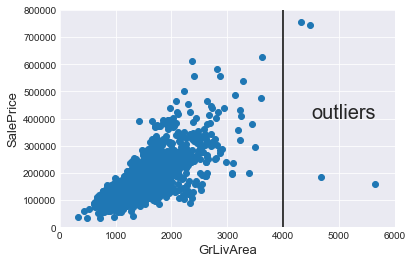

```python
## GrLiveArea열 vs SalePrice열 상의 이상치 확인
plt.scatter(x = train['GrLivArea'], y = train['SalePrice'])
plt.vlines(4000, 0, 800000)
plt.text(4500, 400000, 'outliers', fontsize = 20)

plt.xlim((0, 6000))
plt.ylim((0, 800000))
plt.ylabel('SalePrice', fontsize=13)
plt.xlabel('GrLivArea', fontsize=13)
plt.show()
# 우측 하단 이상치 확인
```

```python
# logical indexing으로 이상치 특정함
train[train['GrLivArea']>4000]
```

|  | MSSubClass | MSZoning | LotFrontage | LotArea | Street | Alley | LotShape | LandContour | LotConfig | LandSlope | ... | PoolArea | PoolQC | Fence | MiscFeature | MiscVal | MoSold | YrSold | SaleType | SaleCondition | SalePrice |
| --- | --- | --- | --- | --- | --- | --- | --- | --- | --- | --- | --- | --- | --- | --- | --- | --- | --- | --- | --- | --- | --- |
| 523 | 60 | RL | 130.0 | 40094 | Pave | None | IR1 | Bnk | Inside | Gtl | ... | 0 | None | None | None | 0 | 10 | 2007 | New | Partial | 184750.0 |
| 691 | 60 | RL | 104.0 | 21535 | Pave | None | IR1 | Lvl | Corner | Gtl | ... | 0 | None | None | None | 0 | 1 | 2007 | WD | Normal | 755000.0 |
| 1182 | 60 | RL | 160.0 | 15623 | Pave | None | IR1 | Lvl | Corner | Gtl | ... | 555 | Ex | MnPrv | None | 0 | 7 | 2007 | WD | Abnorml | 745000.0 |
| 1298 | 60 | RL | 313.0 | 63887 | Pave | None | IR3 | Bnk | Corner | Gtl | ... | 480 | Gd | None | None | 0 | 1 | 2008 | New | Partial | 160000.0 |

4 rows × 79 columns

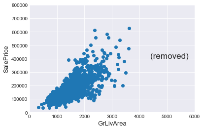

```python
train = train.drop(train[train['GrLivArea']>4000].index)

plt.scatter(train['GrLivArea'], train['SalePrice'])
plt.text(4400, 400000, '(removed)', fontsize = 17)

plt.xlim((0, 6000))
plt.ylim((0, 800000))
plt.ylabel('SalePrice', fontsize=13)
plt.xlabel('GrLivArea', fontsize=13)
plt.show()
```

## 4. 특성 엔지니어링

```python
## 숫자형 변수처럼 보이지만 실제로는 범주형 변수인 것들 변형
all_data['MSSubClass'] = all_data['MSSubClass'].apply(str)

all_data['OverallCond'] = all_data['OverallCond'].astype(str)

all_data['YrSold'] = all_data['YrSold'].astype(str)
all_data['MoSold'] = all_data['MoSold'].astype(str)
```

```python
## 라벨 인코딩
from sklearn.preprocessing import LabelEncoder
cols = ('FireplaceQu', 'BsmtQual', 'BsmtCond', 'GarageQual', 'GarageCond',
        'ExterQual', 'ExterCond','HeatingQC', 'PoolQC', 'KitchenQual', 'BsmtFinType1',
        'BsmtFinType2', 'Functional', 'Fence', 'BsmtExposure', 'GarageFinish', 'LandSlope',
        'LotShape', 'PavedDrive', 'Street', 'Alley', 'CentralAir', 'MSSubClass', 'OverallCond',
        'YrSold', 'MoSold')
# process columns, apply LabelEncoder to categorical features
for c in cols:
    lbl = LabelEncoder()
    lbl.fit(list(all_data[c].values))
    all_data[c] = lbl.transform(list(all_data[c].values))

# shape
print('Shape all_data: {}'.format(all_data.shape))
```

```
Shape all_data: (2919, 79)
```

```python
# 층별 넓이 더해서 전체 넓이 특성 생성
all_data['TotalSF'] = all_data['TotalBsmtSF'] + all_data['1stFlrSF'] + all_data['2ndFlrSF']
```

### 4.1 기타 등등: 가변수, skewed 특성의 분포 저장

#### Log transformation으로 종속변수 분포의 왜도 skewness 조정하기

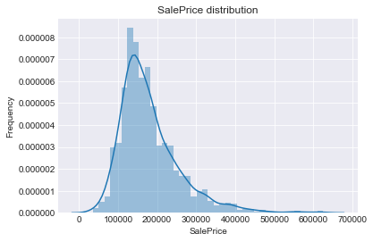

```python
sns.distplot(train['SalePrice'])

plt.ylabel('Frequency')
plt.title('SalePrice distribution')
plt.show()
```

```
180151.2335164835 76670.24989058504
```

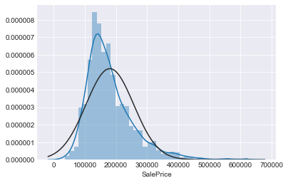

```python
sns.distplot(train['SalePrice'] , fit=norm)

(mu, sigma) = norm.fit(train['SalePrice'])
print(mu, sigma)
plt.show()
```

- https://data.library.virginia.edu/understanding-q-q-plots/
- quantile-quantile plot help us assess if a set of data plausibly came from some theoretical distribution.
- it's a scatterplot created by plotting two sets of quantiles against one another. If both sets of quantiles came from the same distribution, should see points forming a line, roughly straight.

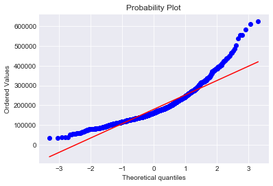

```python
stats.probplot(train['SalePrice'], dist='norm', plot=plt)
plt.show()
```

```
12.021949506725813 0.3959412098902504
```

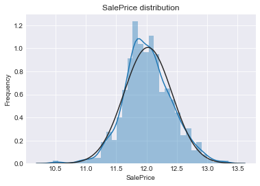

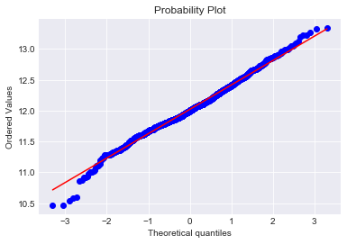

```python
train["SalePrice"] = np.log1p(train["SalePrice"]) # applies log(1+x) to the column
# add 1 for small input values to avoid cases: log(0) = -inf by rounding error and increased accuracy

sns.distplot(train['SalePrice'] , fit=norm);

(mu, sigma) = norm.fit(train['SalePrice'])
print(mu, sigma)

plt.ylabel('Frequency')
plt.title('SalePrice distribution')

fig = plt.figure()
res = stats.probplot(train['SalePrice'], plot=plt)
plt.show()
```

- 종속변수 분포의 왜도가 줄어들고 가우시안 분포에 가까워졌다
- 향후, predict할 때 np.expm1 사용

```python
np.expm1(np.log1p(200000)) # 다시 값 복원하는 방법
```

```
199999.99999999997
```